# Modele generalizate de rang scăzut

# Modele generalizate de rang scăzut

DESCRIERE GENERALĂ

Modelele generalizate de rang scăzut (GLRM) reprezintă o modalitate de reducere a dimensiunii unui set de date prin realizarea unei reprezentări vectoriale condensate pentru fiecare linie și coloană din setul de date original. Liniile și coloanele condensate din matricele X și Y le vom numi implicit arhietipuri, deoarece sunt o reprezentare a caracteristicilor și observațiilor originale.

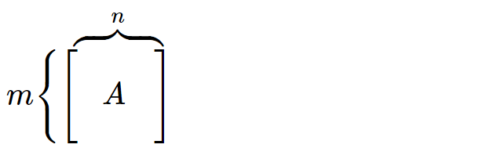

# Modele generalizate de rang scăzut

DESCRIERE GENERALĂ

Modelele generalizate de rang scăzut (GLRM) reprezintă o modalitate de reducere a dimensiunii unui set de date prin realizarea unei reprezentări vectoriale condensate pentru fiecare linie și coloană din setul de date original. Liniile și coloanele condensate din matricele X și Y le vom numi implicit arhietipuri, deoarece sunt o reprezentare a caracteristicilor și observațiilor originale.

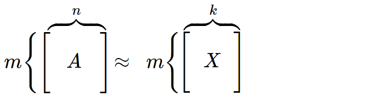

# Modele generalizate de rang scăzut

DESCRIERE GENERALĂ

Modelele generalizate de rang scăzut (GLRM) reprezintă o modalitate de reducere a dimensiunii unui set de date prin realizarea unei reprezentări vectoriale condensate pentru fiecare linie și coloană din setul de date original. Liniile și coloanele condensate din matricele X și Y le vom numi implicit arhietipuri, deoarece sunt o reprezentare a caracteristicilor și observațiilor originale.

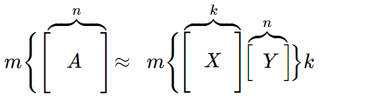

# Modele generalizate de rang scăzut

Etapele realizării unui GLRM  
1. Stabilirea setului de date.  
2. Alegrea rangului k  
3. Funcţia de pierdere.  
4. Funcțiile de regularizare  
5. Determinarea parametrilor optimi  
6. Vizualizarea arhietipurilor.  
7. Reconstructia datelor de intrare

# Modele generalizate de rang scăzut

PAS 1.  
Stabilirea setului de date

```r
library(palmerpenguins)
data(package = 'palmerpenguins')
```

[output not shown]

Vizualizarea relației dintre date

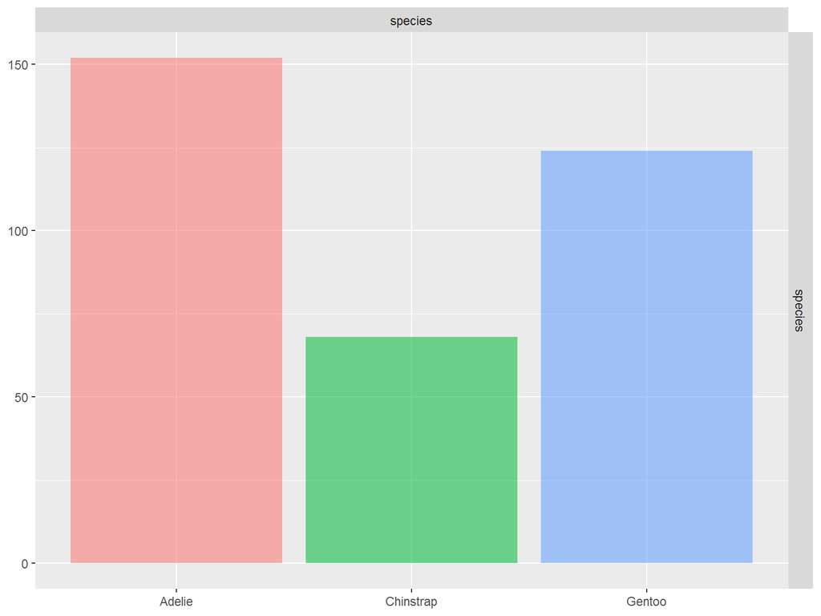

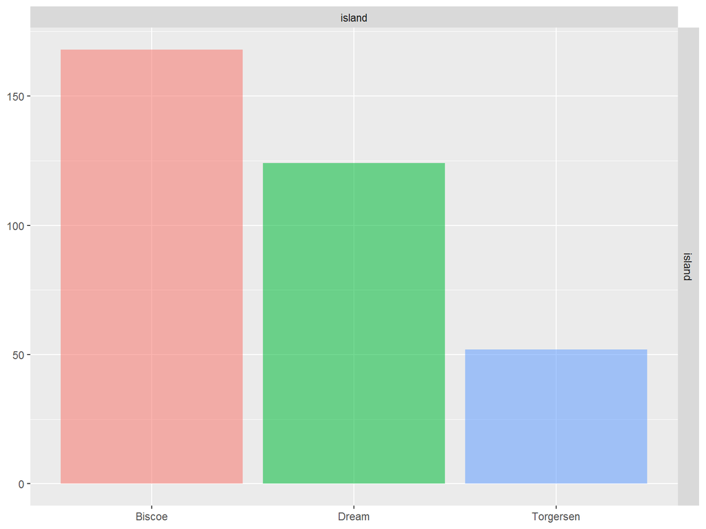

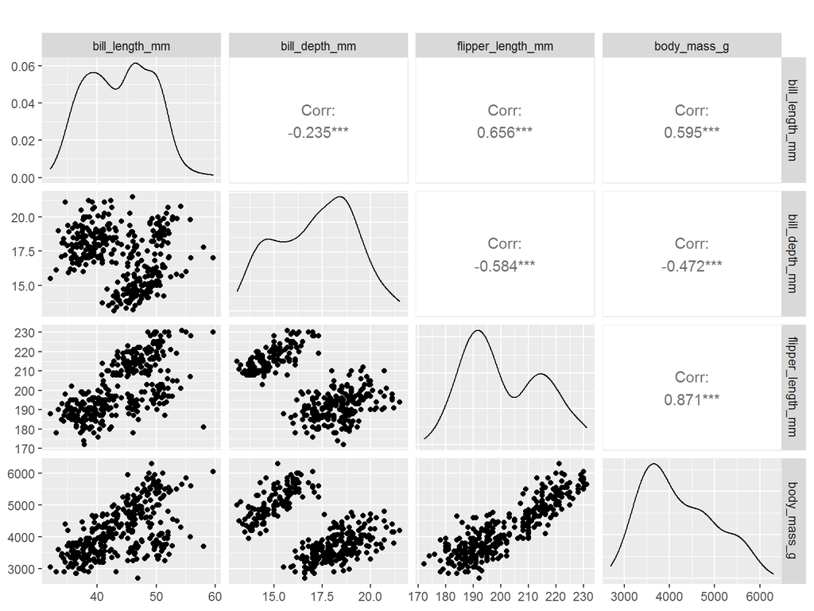

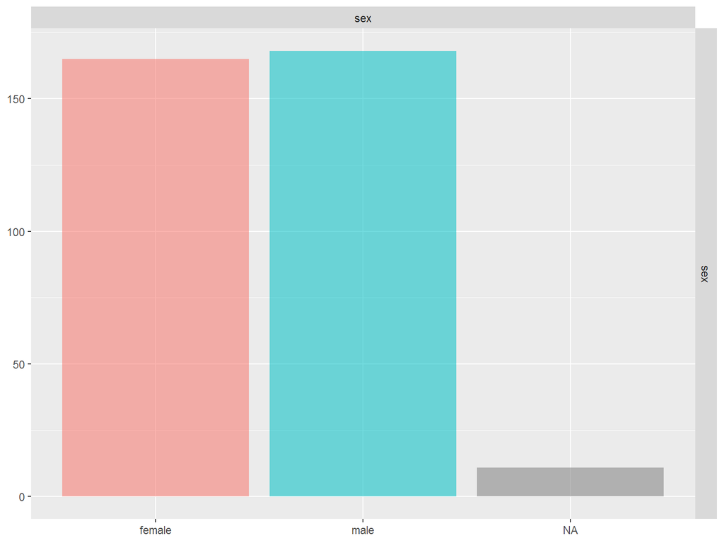

În continuare vom utiliza pachetul h2o, recomandat pentru implementarea GLRM-urilor în R.

```r
library(h2o) #instalarea pachetului
h2o.no_progress()  # dezactivarea barei de progres
h2o.init(max_mem_size = "5g")  # conectarea la instanța H2O
```

```r
# convertirea setului de date într-un obiect h2o
penguins.h2o <- as.h2o(penguins)
penguins.h2o
```

# Modele generalizate de rang scăzut

PAS 2.  
Selectarea lui k

```r
basic_glrm <- h2o.glrm(
  training_frame = penguins.h2o,
  k = 6,
)
```

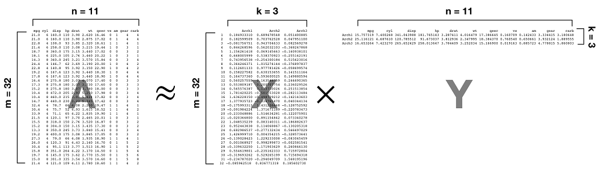

# Modele generalizate de rang scăzut

PAS 3.  
Funcția de pierdere

Valorile optime ale arhietipului sunt selectate pe baza minimizării unei anumite funcții de pierdere. Funcția de pierdere ar trebui să reflecte noțiunea intuitivă a ceea ce înseamnă „a se potrivi bine cu datele”. Cea mai comună funcție de pierdere este pierderea pătratică.

```r
basic_glrm <- h2o.glrm(
  training_frame = penguins.h2o,
  k = 6,
  loss = "Quadratic",
)
```

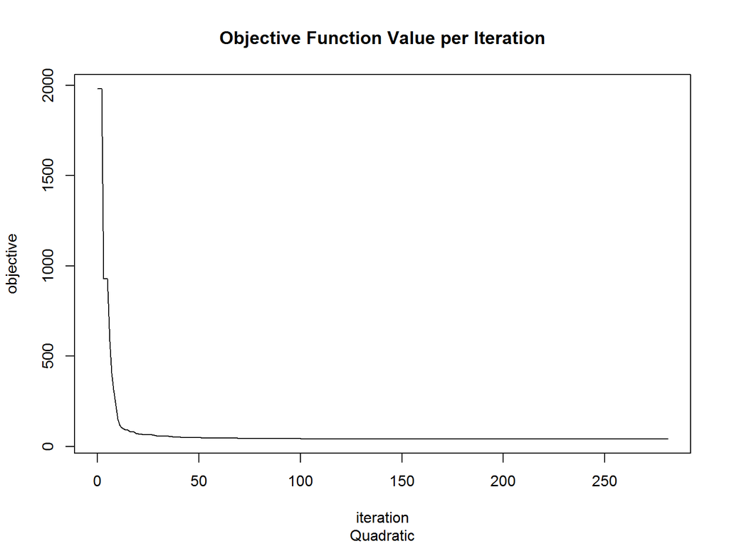

[figure not shown]

# Modele generalizate de rang scăzut

PAS 4.  
Funcțiile de regularizare

O altă componentă importantă pentru adaptarea GLRM-urilor pe care ar trebui să o luăm în considerare este regularizarea. Chiar și atunci când ne concentrăm pe reducerea dimensiunii, aplicarea regularizării matricei X poate încă îmbunătăți performanța. În consecință, este o bună practică să comparăm diferite abordări.

```r
basic_glrm <- h2o.glrm(
  training_frame = penguins.h2o,
  k = 6,
  loss = "Quadratic",
  regularization_x = "None", #tip de regulator aplicat matricei X
  regularization_y = "None", #tip de regulator aplicat matricei Y
)
```

```
## Model Details:
## ==============
##
## H2ODimReductionModel: glrm
## Model Key:  GLRM_model_R_1640899356203_64
## Model Summary:
##   number_of_iterations final_step_size final_objective_value
## 1                  234         0.00009              44.45780
##
## H2ODimReductionMetrics: glrm
## ** Reported on training data. **
##
## Sum of Squared Error (Numeric):  44.45675
## Misclassification Error (Categorical):  0
## Number of Numeric Entries:  1712
## Number of Categorical Entries:  1021
##
##
##
## Scoring History:
##             timestamp   duration iterations step_size  objective
## 1 2021-12-30 23:52:47  0.023 sec          0   0.66667 1968.91401
## 2 2021-12-30 23:52:47  0.025 sec          1   0.44444 1968.91401
## 3 2021-12-30 23:52:47  0.027 sec          2   0.22222 1968.91401
## 4 2021-12-30 23:52:47  0.029 sec          3   0.23333  881.45156
## 5 2021-12-30 23:52:47  0.030 sec          4   0.15556  881.45156
##
## ---
##               timestamp   duration iterations step_size objective
## 229 2021-12-30 23:52:48  0.372 sec        228   0.00018  44.46038
## 230 2021-12-30 23:52:48  0.373 sec        229   0.00012  44.46038
## 231 2021-12-30 23:52:48  0.375 sec        230   0.00012  44.45965
## 232 2021-12-30 23:52:48  0.376 sec        231   0.00013  44.45882
## 233 2021-12-30 23:52:48  0.378 sec        232   0.00014  44.45780
## 234 2021-12-30 23:52:48  0.379 sec        233   0.00009  44.45780
```

```r
basic_glrm_1 <- h2o.glrm(
  training_frame = penguins.h2o,
  k = 6,
  loss = "Quadratic",
  regularization_x = "NonNegative", #tip de regulator aplicat matricei X
  regularization_y = "NonNegative", #tip de regulator aplicat matricei Y
)
```

```
## Model Details:
## ==============
##
## H2ODimReductionModel: glrm
## Model Key:  GLRM_model_R_1640899356203_66
## Model Summary:
##   number_of_iterations final_step_size final_objective_value
## 1                  208         0.00008            2843.55168
##
## H2ODimReductionMetrics: glrm
## ** Reported on training data. **
##
## Sum of Squared Error (Numeric):  891.5736
## Misclassification Error (Categorical):  133
## Number of Numeric Entries:  1712
## Number of Categorical Entries:  1021
##
##
##
## Scoring History:
##             timestamp   duration iterations step_size  objective
## 1 2021-12-30 23:52:49  0.017 sec          0   1.05000 3925.31128
## 2 2021-12-30 23:52:49  0.018 sec          1   0.70000 3925.31128
## 3 2021-12-30 23:52:49  0.020 sec          2   0.46667 3925.31128
## 4 2021-12-30 23:52:49  0.021 sec          3   0.31111 3925.31128
## 5 2021-12-30 23:52:49  0.023 sec          4   0.15556 3925.31128
##
## ---
##               timestamp   duration iterations step_size  objective
## 203 2021-12-30 23:52:49  0.319 sec        202   0.00015 2843.55512
## 204 2021-12-30 23:52:49  0.320 sec        203   0.00010 2843.55512
## 205 2021-12-30 23:52:49  0.322 sec        204   0.00011 2843.55365
## 206 2021-12-30 23:52:49  0.323 sec        205   0.00011 2843.55263
## 207 2021-12-30 23:52:49  0.324 sec        206   0.00012 2843.55168
## 208 2021-12-30 23:52:49  0.326 sec        207   0.00008 2843.55168
```

# Modele generalizate de rang scăzut

PAS 5.  
Determinarea parametrilor optimi

```r
# rularea modelului implicit GLMR

basic_glrm <- h2o.glrm(
  training_frame = penguins.h2o,
  k = 6,
  loss = "Quadratic",
  regularization_x = "None",
  regularization_y = "None",
  transform = "STANDARDIZE",
  max_iterations = 2000,
  seed = 123
)
```

```r
# Viualizarea primelor informații ale modelului
summary(basic_glrm)
```

```
## Model Details:
## ==============
##
## H2ODimReductionModel: glrm
## Model Key:  GLRM_model_R_1640899356203_72
## Model Summary:
##   number_of_iterations final_step_size final_objective_value
## 1                  170         0.00010              49.23136
##
## H2ODimReductionMetrics: glrm
## ** Reported on training data. **
##
## Sum of Squared Error (Numeric):  49.22922
## Misclassification Error (Categorical):  0
## Number of Numeric Entries:  1712
## Number of Categorical Entries:  1021
##
##
##
## Scoring History:
##             timestamp   duration iterations step_size  objective
## 1 2021-12-30 23:52:52  0.013 sec          0   0.66667 4616.21863
## 2 2021-12-30 23:52:52  0.015 sec          1   0.44444 4616.21863
## 3 2021-12-30 23:52:52  0.016 sec          2   0.22222 4616.21863
## 4 2021-12-30 23:52:52  0.018 sec          3   0.23333 1637.25997
## 5 2021-12-30 23:52:52  0.020 sec          4   0.24500  711.94571
##
## ---
##               timestamp   duration iterations step_size objective
## 165 2021-12-30 23:52:53  0.248 sec        164   0.00019  49.23547
## 166 2021-12-30 23:52:53  0.250 sec        165   0.00012  49.23547
## 167 2021-12-30 23:52:53  0.251 sec        166   0.00013  49.23422
## 168 2021-12-30 23:52:53  0.253 sec        167   0.00014  49.23264
## 169 2021-12-30 23:52:53  0.254 sec        168   0.00014  49.23136
## 170 2021-12-30 23:52:53  0.256 sec        169   0.00010  49.23136
```

# Modele generalizate de rang scăzut

PAS 6.  
Vizualizarea arhietipurilor

```r
# Vizualizarea arhietipurilor
p<-t(basic_glrm@model$archetypes)
p
```

```
##                        Arch1      Arch2      Arch3      Arch4       Arch5
## speciesadelie      3.5760171 -1.0536970 -1.8359718  1.4976190  1.62629344
## specieschinstrap  -3.1623256 -2.5650113  1.3593199 -1.7228294 -1.52069278
## speciesgentoo     -2.5493861  1.6574210 -2.0600007 -2.4712381 -2.26522616
## islandbiscoe      -1.0142876  4.1690872 -1.5270332 -0.8677960 -1.16713151
## islanddream       -2.3047539 -1.1672576  3.3946089  0.8297506  1.30537065
## islandtorgersen    1.2008432 -2.3314157 -2.8123334 -1.3726050 -1.10044653
## sexfemale         -2.3965993 -2.6130119 -1.7261563  1.6050346  2.39132500
## sexmale            2.3967727  2.6123513  1.7262586 -1.6049996 -2.39150944
## bill_length_mm    -0.4658475 -0.2331079  1.5042540 -0.9487736 -1.90086009
## bill_depth_mm      1.5029627 -0.6863778  1.1766047  0.2598553  0.01306886
## flipper_length_mm -1.1463152  1.5157226 -0.5185443 -0.4781496 -1.14077952
## body_mass_g       -0.7310272  1.9253201 -0.6281398 -0.9561725 -0.73293141
## year              -0.5955752  0.1199127 -0.2546648  3.5875071 -2.32414953
##                         Arch6
## speciesadelie     -2.09164142
## specieschinstrap  -1.61856249
## speciesgentoo      1.58864252
## islandbiscoe       4.07298741
## islanddream       -2.21080731
## islandtorgersen   -1.70673819
## sexfemale          2.23508080
## sexmale           -2.23446487
## bill_length_mm     1.20263844
## bill_depth_mm     -0.95833432
## flipper_length_mm  0.01452162
## body_mass_g       -0.30976629
## year              -0.47085997
```

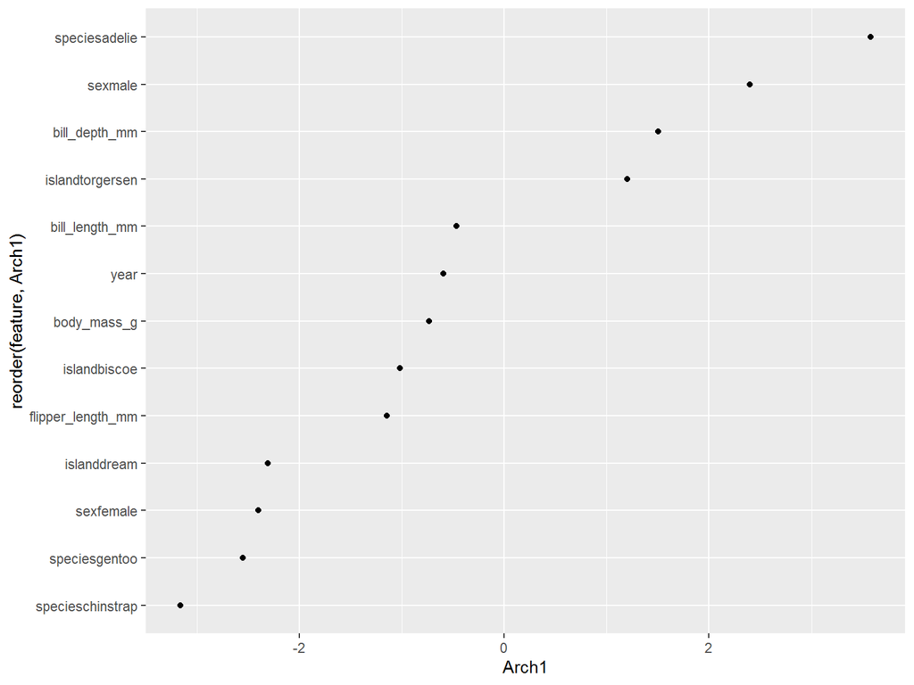

```r
p1 <- t(basic_glrm@model$archetypes) %>%
  as.data.frame() %>%
  mutate(feature = row.names(.)) %>%
  ggplot(aes(Arch1, reorder(feature, Arch1))) +
  geom_point()
plot(p1)
```

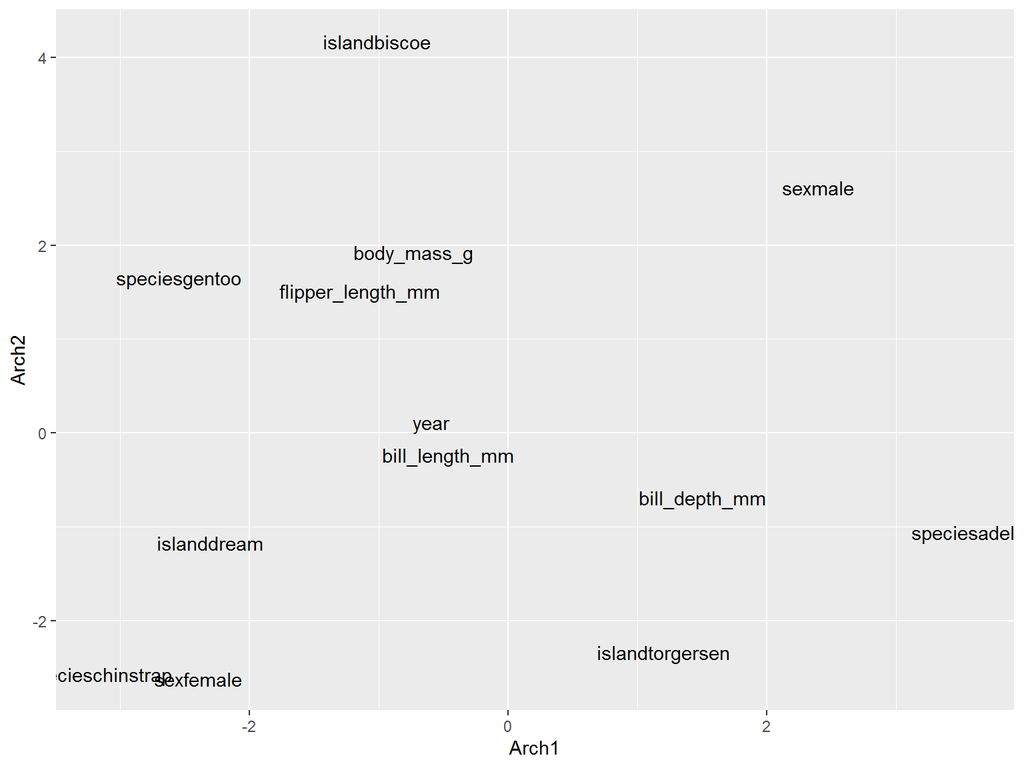

```r
p2 <- t(basic_glrm@model$archetypes) %>%
  as.data.frame() %>%
  mutate(feature = row.names(.)) %>%
  ggplot(aes(Arch1, Arch2, label = feature)) +
  geom_text()
plot(p2)
```

# Modele generalizate de rang scăzut

PAS 7.  
Reconstruirea datelor initiale

```r
my_reconstruction <- h2o.reconstruct(basic_glrm,penguins.h2o, reverse_transform = TRUE)

# Raw predicted values
head(data.frame(penguins))
```

```
##   species    island bill_length_mm bill_depth_mm flipper_length_mm body_mass_g
## 1  Adelie Torgersen           39.1          18.7               181        3750
## 2  Adelie Torgersen           39.5          17.4               186        3800
## 3  Adelie Torgersen           40.3          18.0               195        3250
## 4  Adelie Torgersen             NA            NA                NA          NA
## 5  Adelie Torgersen           36.7          19.3               193        3450
## 6  Adelie Torgersen           39.3          20.6               190        3650
##      sex year
## 1   male 2007
## 2 female 2007
## 3 female 2007
## 4   <NA> 2007
## 5 female 2007
## 6   male 2007
```

```r
head(my_reconstruction)
```

```
##   reconstr_species reconstr_island reconstr_bill_length_mm
## 1           Adelie       Torgersen                38.92334
## 2           Adelie       Torgersen                38.98510
## 3           Adelie       Torgersen                40.36339
## 4           Adelie       Torgersen                37.97307
## 5           Adelie       Torgersen                37.01738
## 6           Adelie       Torgersen                39.63512
##   reconstr_bill_depth_mm reconstr_flipper_length_mm reconstr_body_mass_g
## 1               19.16238                   185.4733             3677.575
## 2               17.59515                   188.0536             3628.206
## 3               17.77523                   186.9626             3521.575
## 4               18.83994                   184.5396             3580.994
## 5               18.13613                   184.7563             3493.604
## 6               20.34573                   185.6272             3807.050
##   reconstr_sex reconstr_year
## 1         male      2006.968
## 2       female      2006.989
## 3       female      2007.064
## 4         male      2007.000
## 5       female      2007.056
## 6         male      2007.032
```

```r
perf <- h2o.performance(basic_glrm)
perf
```

```
## H2ODimReductionMetrics: glrm
## ** Reported on training data. **
##
## Sum of Squared Error (Numeric):  49.22922
## Misclassification Error (Categorical):  0
## Number of Numeric Entries:  1712
## Number of Categorical Entries:  1021
```

```r
basic_glrm
```

```
## Model Details:
## ==============
##
## H2ODimReductionModel: glrm
## Model ID:  GLRM_model_R_1640899356203_72
## Model Summary:
##   number_of_iterations final_step_size final_objective_value
## 1                  170         0.00010              49.23136
##
##
## H2ODimReductionMetrics: glrm
## ** Reported on training data. **
##
## Sum of Squared Error (Numeric):  49.22922
## Misclassification Error (Categorical):  0
## Number of Numeric Entries:  1712
## Number of Categorical Entries:  1021
```